# Small seeding models for Tony & Kevin

Kathleen Stutzman

2024-01-25

Hidden below is code for importing the data set and log transforming variables. The best model (lowest AIC & using lrtest) is presented below, model fit checked, and pairwise comparison for Treatment Type.

I did create and test models without treatment type, but they always have higher AIC and worse model fit that those with (probably due to the control category…)

##### Variables investigated:

- **Treat_Type** - treatment type
- **PIRI** - pitch pine seedling count
- **SO** - shrub oak seedling count
- **other** - other seedling count
- **BA_HA** - basal area per hectare
- **BA_piri** - pitch pine basal area per hectare
- **Mineral** - exposed mineral soil
- **avgLD** - average leaf litter depth
- **Veg_Total** - total understory plant cover
- **TFT** - time between treatment and sampling (used as an offset)
- **Site/Plot_No** - random effect of plots within sites

Variables are log transformed (l. or _l)

## Pitch Pine Regeneration

### Best small seedling pitch pine model

```r
ss.m4 <- glmmTMB(PIRI ~ Treat_Type + l.SO + avgLD_l + l.Veg_Total + offset(l.TFT) + (1|Site/Plot_No),
                 data = ss.all2,
                 family = poisson)
summary(ss.m4)
```

```
##  Family: poisson  ( log )
## Formula:
## PIRI ~ Treat_Type + l.SO + avgLD_l + l.Veg_Total + offset(l.TFT) +
##     (1 | Site/Plot_No)
## Data: ss.all2
##
##      AIC      BIC   logLik deviance df.resid
##    722.6    764.7   -351.3    702.6      488
##
## Random effects:
##
## Conditional model:
##  Groups       Name        Variance Std.Dev.
##  Plot_No:Site (Intercept) 4.657    2.158
##  Site         (Intercept) 2.247    1.499
## Number of obs: 498, groups:  Plot_No:Site, 498; Site, 47
##
## Conditional model:
##                    Estimate Std. Error z value   Pr(>|z|)
## (Intercept)         -5.2307     1.7872  -2.927    0.00343 **
## Treat_TypeFallRx     6.8811     1.4362   4.791 0.00000166 ***
## Treat_TypeHarvest    6.4777     1.5012   4.315 0.00001595 ***
## Treat_TypeMowRx      5.2753     1.4183   3.719    0.00020 ***
## Treat_TypeSpringRx   6.7837     1.4407   4.709 0.00000249 ***
## l.SO                -0.5172     0.2390  -2.164    0.03049 *
## avgLD_l             -1.1967     0.4340  -2.757    0.00583 **
## l.Veg_Total         -0.8041     0.3280  -2.451    0.01423 *
## ---
## Signif. codes:  0 '***' 0.001 '**' 0.01 '*' 0.05 '.' 0.1 ' ' 1
```

#### Check model fit

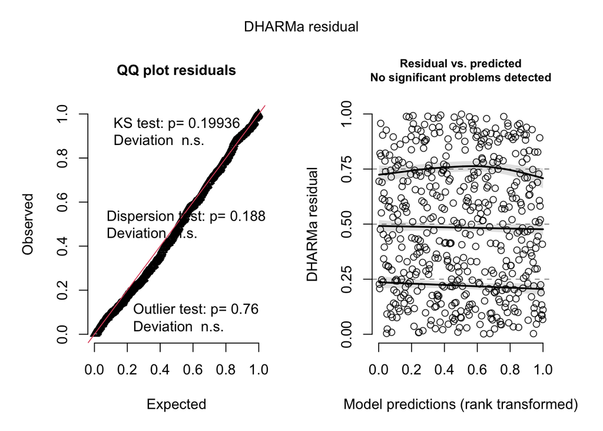

```r
ss.m4_sr <- simulateResiduals(ss.m4, n = 1000, plot = TRUE) #looks pretty good
```

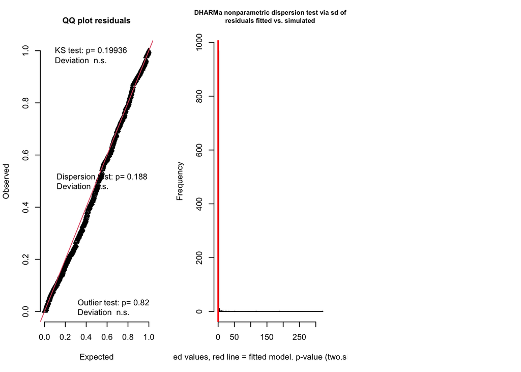

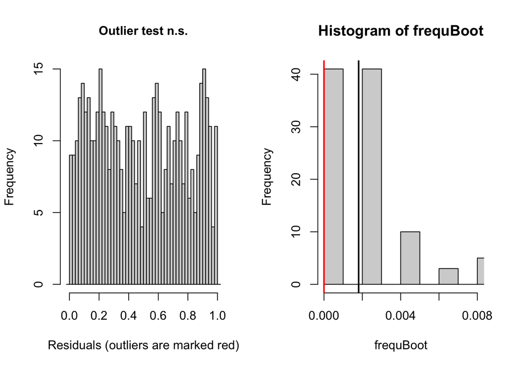

```
## $uniformity
##
##  Asymptotic one-sample Kolmogorov-Smirnov test
##
## data:  simulationOutput$scaledResiduals
## D = 0.048104, p-value = 0.1994
## alternative hypothesis: two-sided
##
##
## $dispersion
##
##  DHARMa nonparametric dispersion test via sd of residuals fitted vs.
##  simulated
##
## data:  simulationOutput
## dispersion = 0.0024587, p-value = 0.188
## alternative hypothesis: two.sided
##
##
## $outliers
##
##  DHARMa bootstrapped outlier test
##
## data:  simulationOutput
## outliers at both margin(s) = 0, observations = 498, p-value = 0.82
## alternative hypothesis: two.sided
##  percent confidence interval:
##  0.000000000 0.008032129
## sample estimates:
## outlier frequency (expected: 0.00180722891566265 )
##                                                  0
```

```
## $uniformity
##
##  Asymptotic one-sample Kolmogorov-Smirnov test
##
## data:  simulationOutput$scaledResiduals
## D = 0.048104, p-value = 0.1994
## alternative hypothesis: two-sided
##
##
## $dispersion
##
##  DHARMa nonparametric dispersion test via sd of residuals fitted vs.
##  simulated
##
## data:  simulationOutput
## dispersion = 0.0024587, p-value = 0.188
## alternative hypothesis: two.sided
##
##
## $outliers
##
##  DHARMa bootstrapped outlier test
##
## data:  simulationOutput
## outliers at both margin(s) = 0, observations = 498, p-value = 0.82
## alternative hypothesis: two.sided
##  percent confidence interval:
##  0.000000000 0.008032129
## sample estimates:
## outlier frequency (expected: 0.00180722891566265 )
##                                                  0
```

```r
testResiduals(ss.m4_sr) #passes uniformity, dispersion, and outliers
```

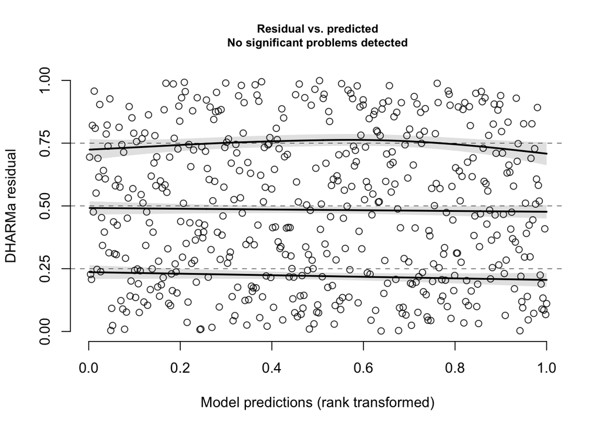

```
##
##  Test for location of quantiles via qgam
##
## data:  simulationOutput
## p-value = 0.2206
## alternative hypothesis: both
```

```r
testQuantiles(ss.m4_sr) #passes
```

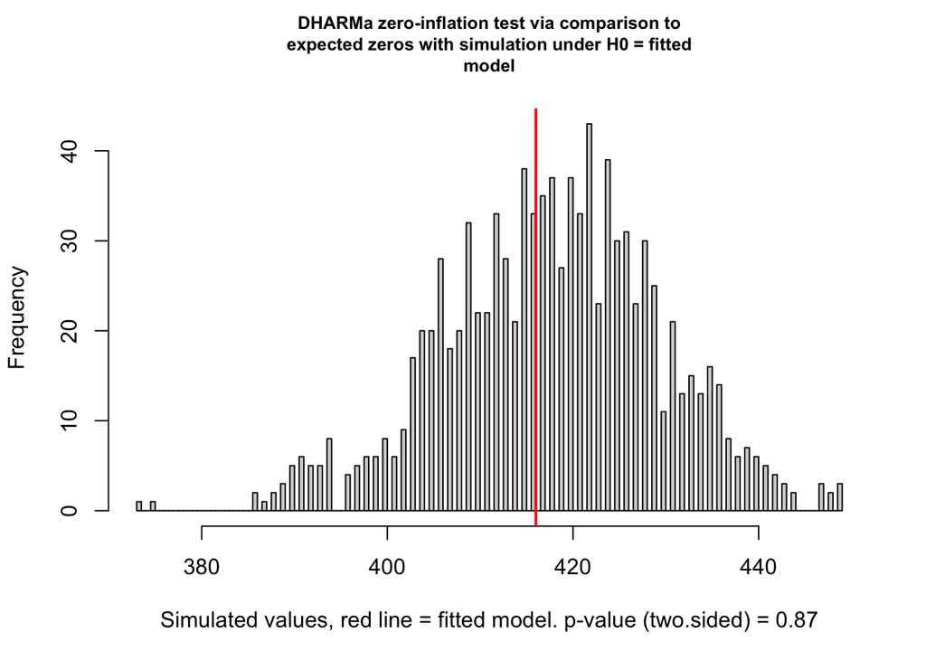

```
##
##  DHARMa zero-inflation test via comparison to expected zeros with
##  simulation under H0 = fitted model
##
## data:  simulationOutput
## ratioObsSim = 0.99532, p-value = 0.87
## alternative hypothesis: two.sided
```

```r
testZeroInflation(ss.m4_sr) #passes
```

#### Pairwise for treatment type

```r
emmeans(ss.m4, specs = pairwise ~ Treat_Type, adjust = 'Tukey', type = 'response')
```

```
## $emmeans
##  Treat_Type     rate       SE  df asymp.LCL asymp.UCL
##  Control    0.000147 0.000196 Inf 0.0000108     0.002
##  FallRx     0.143092 0.098074 Inf 0.0373430     0.548
##  Harvest    0.095594 0.081151 Inf 0.0181066     0.505
##  MowRx      0.028723 0.019958 Inf 0.0073586     0.112
##  SpringRx   0.129822 0.093714 Inf 0.0315422     0.534
##
## Confidence level used: 0.95
## Intervals are back-transformed from the log scale
##
## $contrasts
##  contrast             ratio      SE  df null z.ratio p.value
##  Control / FallRx   0.00103 0.00147 Inf    1  -4.791  <.0001
##  Control / Harvest  0.00154 0.00231 Inf    1  -4.315  0.0002
##  Control / MowRx    0.00512 0.00726 Inf    1  -3.719  0.0019
##  Control / SpringRx 0.00113 0.00163 Inf    1  -4.709  <.0001
##  FallRx / Harvest   1.49687 1.48518 Inf    1   0.407  0.9943
##  FallRx / MowRx     4.98172 4.23482 Inf    1   1.889  0.3232
##  FallRx / SpringRx  1.10222 0.97175 Inf    1   0.110  1.0000
##  Harvest / MowRx    3.32809 3.28617 Inf    1   1.218  0.7411
##  Harvest / SpringRx 0.73635 0.73882 Inf    1  -0.305  0.9981
##  MowRx / SpringRx   0.22125 0.18896 Inf    1  -1.766  0.3935
##
## P value adjustment: tukey method for comparing a family of 5 estimates
## Tests are performed on the log scale
```

#### Graph pitch pine models

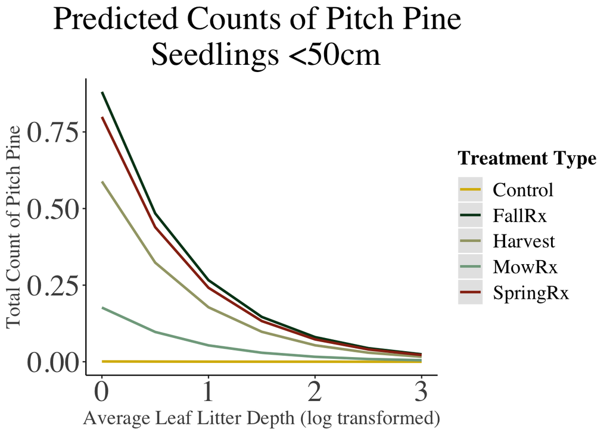

```r
library(sjPlot)
library(sjlabelled)
library(sjmisc)

set_theme(base = theme_classic(),
          theme.font = 'serif',
          axis.title.size = 1.5,
          axis.textsize.x = 1.5,
          axis.textsize.y = 1.5,
          title.size = 2.5,
          title.align = "center",
          legend.pos = "right",
          legend.size = 1.5,
          legend.title.size = 1.5,
          #legend.bordercol = "black",
          legend.item.size = .75)

# SS PIRI plot 1 ------------------- LD vs. TT
plot_model(ss.m4,
                       type = 'pred',
                       terms = c('avgLD_l', 'Treat_Type'),
                       axis.title = c("Average Leaf Litter Depth (log transformed)", "Total Count of Pitch Pine"),
                       title = "Predicted Counts of Pitch Pine \n Seedlings <50cm",
           legend.title = "Treatment Type",
           line.size = 1,
           value.offset = 'Treat_Type',
           ci.lvl = NA,
           colors = c("#D8B70A", "#02401B", "#A2A475", "#81A88D", "#972D15"))
```

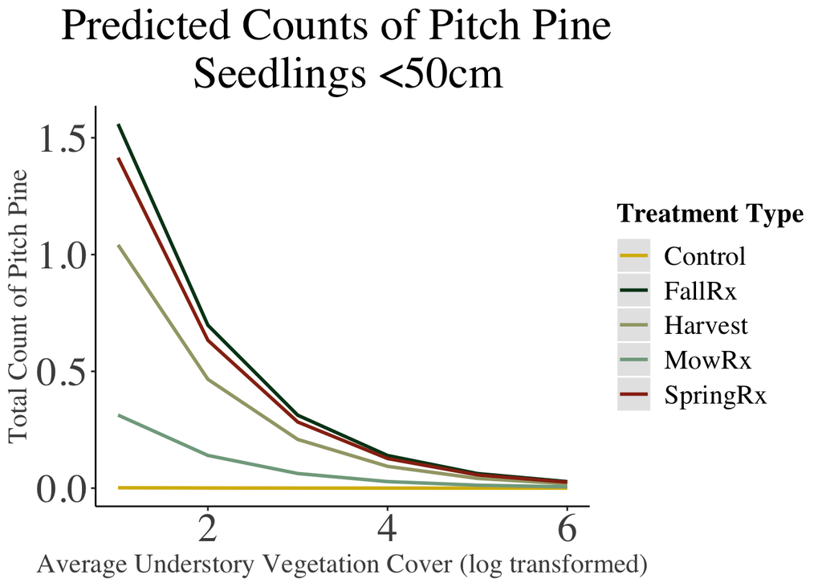

```r
# SS PIRI plot 2 ------------------- Veg vs TT
plot_model(ss.m4,
                       type = 'pred',
                       terms = c('l.Veg_Total', 'Treat_Type'),
                       axis.title = c("Average Understory Vegetation Cover (log transformed)", "Total Count of Pitch Pine"),
                       title = "Predicted Counts of Pitch Pine \n Seedlings <50cm",
           legend.title = "Treatment Type",
           line.size = 1,
           value.offset = 'Treat_Type',
           ci.lvl = NA,
           colors = c("#D8B70A", "#02401B", "#A2A475", "#81A88D", "#972D15"))
```

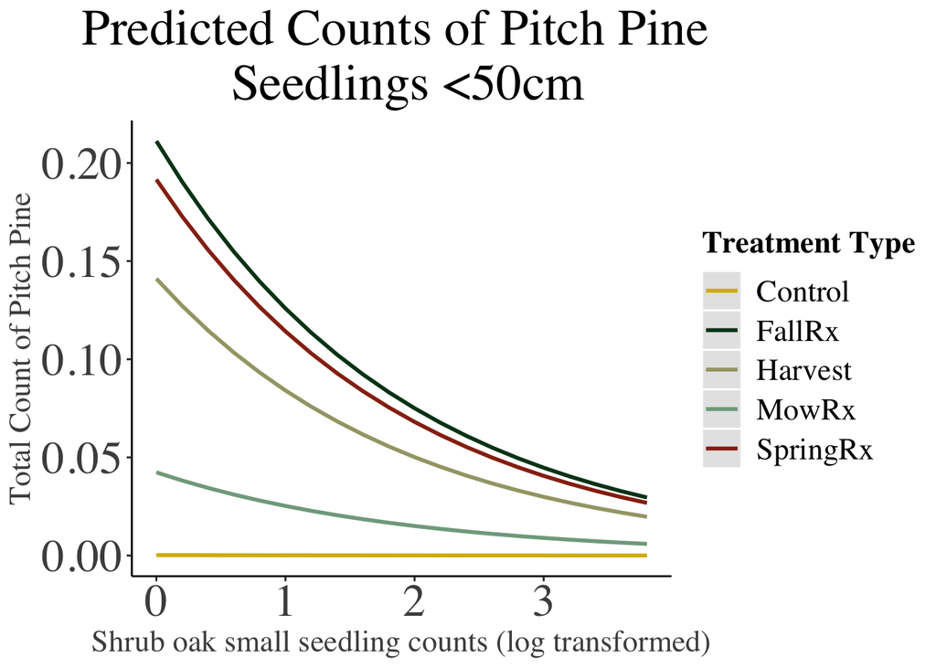

```r
# SS PIRI pot 3 ------------------- Shrub Oak seedling vs TT
plot_model(ss.m4,
                       type = 'pred',
                       terms = c('l.SO', 'Treat_Type'),
                       axis.title = c("Shrub oak small seedling counts (log transformed)", "Total Count of Pitch Pine"),
                       title = "Predicted Counts of Pitch Pine \n Seedlings <50cm",
           legend.title = "Treatment Type",
           line.size = 1,
           value.offset = 'Treat_Type',
           ci.lvl = NA,
           colors = c("#D8B70A", "#02401B", "#A2A475", "#81A88D", "#972D15"))
```

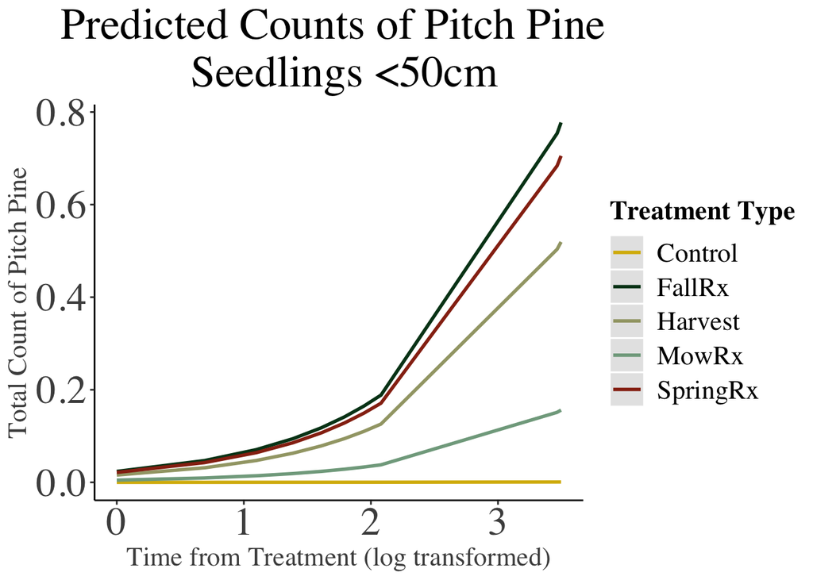

```r
# SS PIRI plot 4 ------------------- Time from Treatment vs TT
plot_model(ss.m4,
                       type = 'pred',
                       terms = c('l.TFT', 'Treat_Type'),
                       axis.title = c("Time from Treatment (log transformed)", "Total Count of Pitch Pine"),
                       title = "Predicted Counts of Pitch Pine \n Seedlings <50cm",
           legend.title = "Treatment Type",
           line.size = 1,
           value.offset = 'Treat_Type',
           ci.lvl = NA,
           colors = c("#D8B70A", "#02401B", "#A2A475", "#81A88D", "#972D15"))
```

## Shrub Oak Regeneration

This includes QUIL (scrub oak) & QUPR (dwarf chinkapin oak)

#### Best small seedling shrub oak model

```r
so.ss11 <- glmmTMB(Shrub_Oak ~ Treat_Type + l.PIRI + offset(l.TFT) + (1|Site/Plot_No),
                 data = ss.all2,
                 family = genpois)
summary(so.ss11)
```

```
##  Family: genpois  ( log )
## Formula:
## Shrub_Oak ~ Treat_Type + l.PIRI + offset(l.TFT) + (1 | Site/Plot_No)
## Data: ss.all2
##
##      AIC      BIC   logLik deviance df.resid
##   1854.2   1892.1   -918.1   1836.2      489
##
## Random effects:
##
## Conditional model:
##  Groups       Name        Variance Std.Dev.
##  Plot_No:Site (Intercept) 0.2882   0.5369
##  Site         (Intercept) 0.9904   0.9952
## Number of obs: 498, groups:  Plot_No:Site, 498; Site, 47
##
## Dispersion parameter for genpois family (): 5.87
##
## Conditional model:
##                    Estimate Std. Error z value             Pr(>|z|)
## (Intercept)         -3.4252     0.3608  -9.493 < 0.0000000000000002 ***
## Treat_TypeFallRx     2.8087     0.5032   5.581       0.000000023864 ***
## Treat_TypeHarvest    1.4256     0.6233   2.287               0.0222 *
## Treat_TypeMowRx      2.9454     0.4699   6.268       0.000000000366 ***
## Treat_TypeSpringRx   2.8173     0.5213   5.404       0.000000065125 ***
## l.PIRI              -0.3657     0.1623  -2.253               0.0242 *
## ---
## Signif. codes:  0 '***' 0.001 '**' 0.01 '*' 0.05 '.' 0.1 ' ' 1
```

#### Check model fit

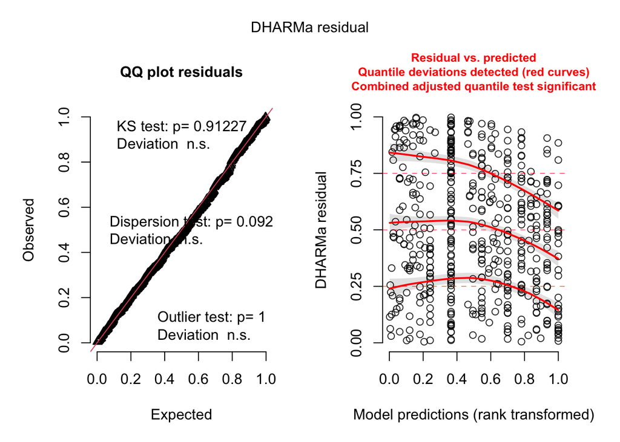

```r
so.ss11_sr <- simulateResiduals(so.ss11, n = 1000, plot = TRUE)
```

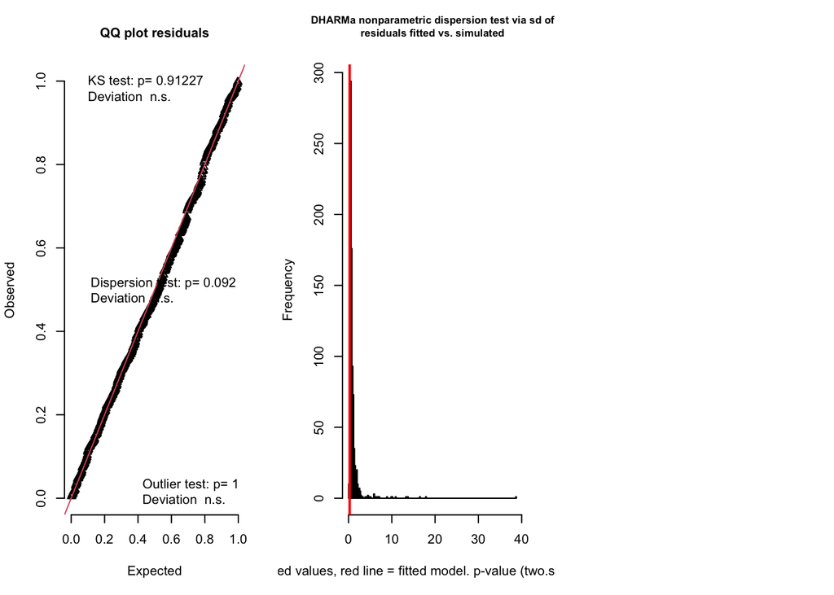

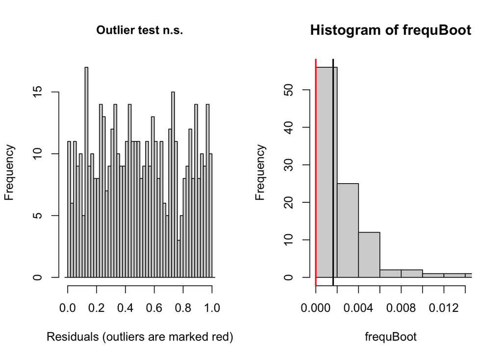

```
## $uniformity
##
##  Asymptotic one-sample Kolmogorov-Smirnov test
##
## data:  simulationOutput$scaledResiduals
## D = 0.025101, p-value = 0.9123
## alternative hypothesis: two-sided
##
##
## $dispersion
##
##  DHARMa nonparametric dispersion test via sd of residuals fitted vs.
##  simulated
##
## data:  simulationOutput
## dispersion = 0.28065, p-value = 0.092
## alternative hypothesis: two.sided
##
##
## $outliers
##
##  DHARMa bootstrapped outlier test
##
## data:  simulationOutput
## outliers at both margin(s) = 0, observations = 498, p-value = 1
## alternative hypothesis: two.sided
##  percent confidence interval:
##  0.000000000 0.009086345
## sample estimates:
## outlier frequency (expected: 0.00162650602409639 )
##                                                  0
```

```
## $uniformity
##
##  Asymptotic one-sample Kolmogorov-Smirnov test
##
## data:  simulationOutput$scaledResiduals
## D = 0.025101, p-value = 0.9123
## alternative hypothesis: two-sided
##
##
## $dispersion
##
##  DHARMa nonparametric dispersion test via sd of residuals fitted vs.
##  simulated
##
## data:  simulationOutput
## dispersion = 0.28065, p-value = 0.092
## alternative hypothesis: two.sided
##
##
## $outliers
##
##  DHARMa bootstrapped outlier test
##
## data:  simulationOutput
## outliers at both margin(s) = 0, observations = 498, p-value = 1
## alternative hypothesis: two.sided
##  percent confidence interval:
##  0.000000000 0.009086345
## sample estimates:
## outlier frequency (expected: 0.00162650602409639 )
##                                                  0
```

```r
testResiduals(so.ss11_sr)
```

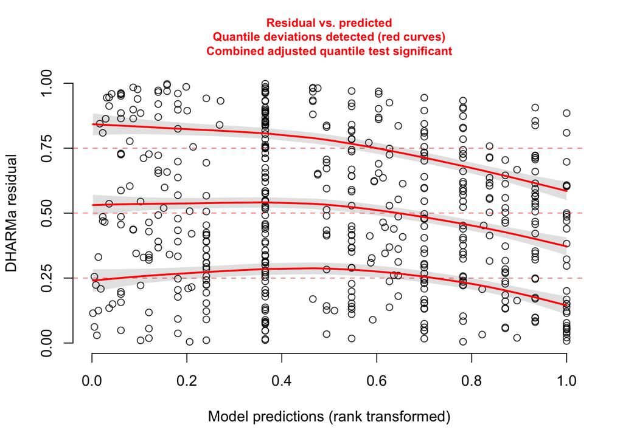

```
##
##  Test for location of quantiles via qgam
##
## data:  simulationOutput
## p-value = 0.00001043
## alternative hypothesis: both
```

```r
testQuantiles(so.ss11_sr) #quantiles are not good
```

From what I’ve read, models with significant quantile deviations can still be good models / used. There are some distribution issues. I’ve switched to genpois distro here, which just barely gets the job done.

#### Pairwise for treatment type

```r
emmeans(so.ss11, specs = pairwise ~ Treat_Type, adjust = 'Tukey', type = 'response')
```

```
## $emmeans
##  Treat_Type response     SE  df asymp.LCL asymp.UCL
##  Control       0.183 0.0666 Inf    0.0898     0.373
##  FallRx        3.038 1.1048 Inf    1.4896     6.196
##  Harvest       0.762 0.4032 Inf    0.2701     2.149
##  MowRx         3.483 1.1174 Inf    1.8574     6.532
##  SpringRx      3.064 1.2098 Inf    1.4134     6.643
##
## Confidence level used: 0.95
## Intervals are back-transformed from the log scale
##
## $contrasts
##  contrast            ratio     SE  df null z.ratio p.value
##  Control / FallRx   0.0603 0.0303 Inf    1  -5.581  <.0001
##  Control / Harvest  0.2404 0.1498 Inf    1  -2.287  0.1489
##  Control / MowRx    0.0526 0.0247 Inf    1  -6.268  <.0001
##  Control / SpringRx 0.0598 0.0312 Inf    1  -5.404  <.0001
##  FallRx / Harvest   3.9873 2.5162 Inf    1   2.192  0.1827
##  FallRx / MowRx     0.8722 0.4141 Inf    1  -0.288  0.9985
##  FallRx / SpringRx  0.9914 0.5212 Inf    1  -0.016  1.0000
##  Harvest / MowRx    0.2188 0.1325 Inf    1  -2.509  0.0885
##  Harvest / SpringRx 0.2486 0.1605 Inf    1  -2.156  0.1966
##  MowRx / SpringRx   1.1367 0.5632 Inf    1   0.259  0.9990
##
## P value adjustment: tukey method for comparing a family of 5 estimates
## Tests are performed on the log scale
```

#### Graph shrub oak seedling model

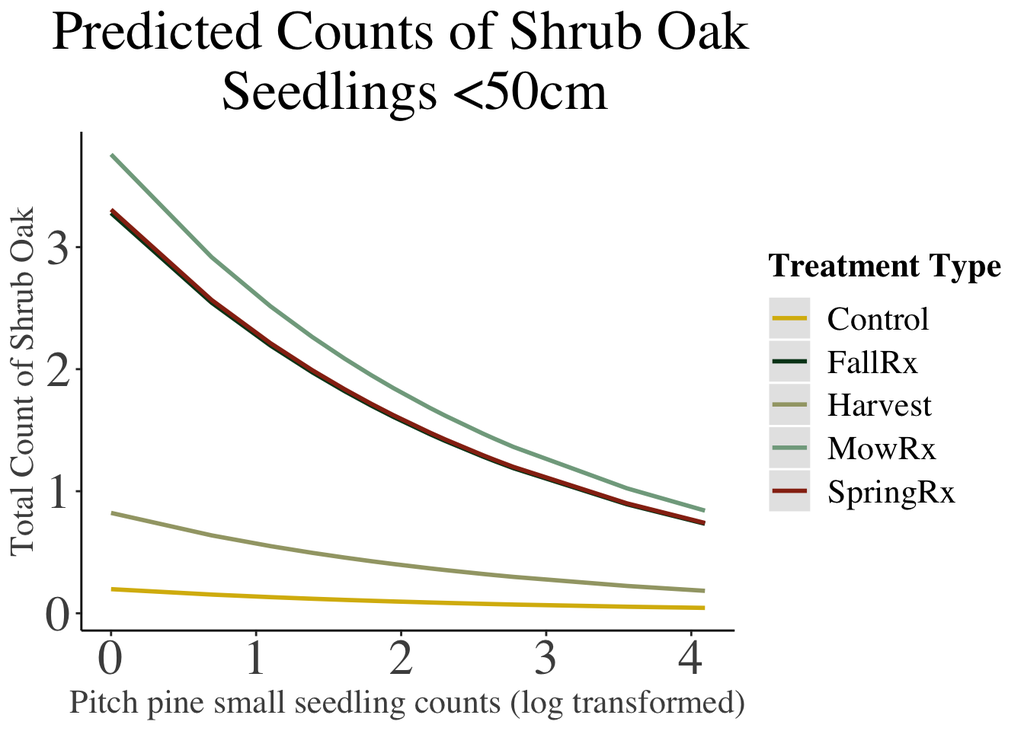

```r
# SS SO plot 1 ------------------- PIRI vs. TT
plot_model(so.ss11,
                       type = 'pred',
                       terms = c('l.PIRI', 'Treat_Type'),
                       axis.title = c("Pitch pine small seedling counts (log transformed)", "Total Count of Shrub Oak"),
                       title = "Predicted Counts of Shrub Oak \n Seedlings <50cm",
           legend.title = "Treatment Type",
           line.size = 1,
           value.offset = 'Treat_Type',
           ci.lvl = NA,
           colors = c("#D8B70A", "#02401B", "#A2A475", "#81A88D", "#972D15"))
```